# PML_Project

TZ

September 25, 2015

## Background

The goal of this project is to use data from accelerometers on the belt, forearm, arm, and dumbell of 6 participants, to predict the manner in which they did the exercise. More information is available from the website here: http://groupware.les.inf.puc-rio.br/har (see the section on the Weight Lifting Exercise Dataset).

## Input Data Preparation

There are 160 variables in the original data set. The data needs to be cleaned up since there are a lot of blank cells, as well as “#DIV/0” and “NA” values. By identifying columns containing these values, the number of variables is reduced to 60. This number is further reduced to 56 by removing the first column with simply the row number and 3 columns with time information.

```r
train<-read.csv("pml-training.csv",na.strings=c("","NA","#DIV/0!"))
train_clean<-train[,colSums(is.na(train))==0]
train_clean<-train_clean[,-1]
train_clean<-train_clean[,-c(2:4)]
```

## Train and predict with Tree

The train data has nearly 20,000 rows. If all these data points are used to create the model, it will be difficult to validate itself before being applied to predict the 20 test cases. A better choice is to split the data into training subset (60%) and testing subset (40%), and use the latter to validate the model fitted by the former.

```r
library(caret)
inTrain<-createDataPartition(y=train_clean$classe,p=0.6,list=FALSE)
training<-train_clean[inTrain,]
testing<-train_clean[-inTrain,]
fit<-train(classe ~.,method="rpart",data=training)
print(fit$finalModel)
```

```
## n= 11776
##
## node), split, n, loss, yval, (yprob)
##       * denotes terminal node
##
##  1) root 11776 8428 A (0.28 0.19 0.17 0.16 0.18)
##    2) roll_belt< 130.5 10771 7429 A (0.31 0.21 0.19 0.18 0.11)
##      4) pitch_forearm< -34.55 931    4 A (1 0.0043 0 0 0) *
##      5) pitch_forearm>=-34.55 9840 7425 A (0.25 0.23 0.21 0.2 0.12)
##       10) num_window>=45.5 9413 6998 A (0.26 0.24 0.22 0.2 0.087)
##         20) magnet_dumbbell_y< 439.5 8022 5650 A (0.3 0.19 0.25 0.19 0.08)
##           40) roll_forearm< 123.5 5024 2894 A (0.42 0.19 0.18 0.17 0.041) *
##           41) roll_forearm>=123.5 2998 1931 C (0.081 0.19 0.36 0.23 0.15) *
##         21) magnet_dumbbell_y>=439.5 1391  624 B (0.031 0.55 0.045 0.25 0.13) *
##       11) num_window< 45.5 427   81 E (0 0 0 0.19 0.81) *
##    3) roll_belt>=130.5 1005    6 E (0.006 0 0 0 0.99) *
```

```r
result<-predict(fit,newdata=testing)
confusionMatrix(result,testing$classe)
```

```
## Confusion Matrix and Statistics
##
##           Reference
## Prediction    A    B    C    D    E
##          A 2020  640  663  539  165
##          B   38  519   45  225  100
##          C  166  359  660  457  318
##          D    0    0    0    0    0
##          E    8    0    0   65  859
##
## Overall Statistics
##
##                Accuracy : 0.5172
##                  95% CI : (0.5061, 0.5283)
##     No Information Rate : 0.2845
##     P-Value [Acc > NIR] : < 2.2e-16
##
##                   Kappa : 0.3695
##  Mcnemar's Test P-Value : < 2.2e-16
##
## Statistics by Class:
##
##                      Class: A Class: B Class: C Class: D Class: E
## Sensitivity            0.9050  0.34190  0.48246   0.0000   0.5957
## Specificity            0.6425  0.93552  0.79932   1.0000   0.9886
## Pos Pred Value         0.5016  0.55987  0.33673      NaN   0.9217
## Neg Pred Value         0.9445  0.85561  0.87971   0.8361   0.9157
## Prevalence             0.2845  0.19347  0.17436   0.1639   0.1838
## Detection Rate         0.2575  0.06615  0.08412   0.0000   0.1095
## Detection Prevalence   0.5133  0.11815  0.24981   0.0000   0.1188
## Balanced Accuracy      0.7738  0.63871  0.64089   0.5000   0.7922
```

## Train and predict with Random Forest

A more accurate model is necessary to better classify the test cases. Since Random Forest takes a long time to run with this large dataset, “resampling” was turned off to speed up the fitting.

```r
fitControl <- trainControl(method = "none")
tgrid <- expand.grid(mtry=c(6))
fit2<-train(classe~ .,data=training,method="rf",trControl=fitControl,tuneGrid=tgrid)
pred<-predict(fit2,testing)
confusionMatrix(pred,testing$classe)
```

```
## Confusion Matrix and Statistics
##
##           Reference
## Prediction    A    B    C    D    E
##          A 2231    5    0    0    0
##          B    1 1511    4    0    0
##          C    0    2 1364   18    0
##          D    0    0    0 1267    6
##          E    0    0    0    1 1436
##
## Overall Statistics
##
##                Accuracy : 0.9953
##                  95% CI : (0.9935, 0.9967)
##     No Information Rate : 0.2845
##     P-Value [Acc > NIR] : < 2.2e-16
##
##                   Kappa : 0.994
##  Mcnemar's Test P-Value : NA
##
## Statistics by Class:
##
##                      Class: A Class: B Class: C Class: D Class: E
## Sensitivity            0.9996   0.9954   0.9971   0.9852   0.9958
## Specificity            0.9991   0.9992   0.9969   0.9991   0.9998
## Pos Pred Value         0.9978   0.9967   0.9855   0.9953   0.9993
## Neg Pred Value         0.9998   0.9989   0.9994   0.9971   0.9991
## Prevalence             0.2845   0.1935   0.1744   0.1639   0.1838
## Detection Rate         0.2843   0.1926   0.1738   0.1615   0.1830
## Detection Prevalence   0.2850   0.1932   0.1764   0.1622   0.1832
## Balanced Accuracy      0.9993   0.9973   0.9970   0.9922   0.9978
```

```r
varImp(fit2,scale=FALSE)
```

```
## rf variable importance
##
##   only 20 most important variables shown (out of 59)
##
##                      Overall
## num_window             695.1
## roll_belt              604.5
## yaw_belt               444.1
## pitch_forearm          400.6
## magnet_dumbbell_z      396.1
## pitch_belt             380.0
## magnet_dumbbell_y      368.3
## roll_forearm           298.1
## magnet_dumbbell_x      285.5
## accel_belt_z           236.2
## roll_dumbbell          229.8
## magnet_belt_y          228.1
## accel_dumbbell_y       225.6
## magnet_belt_z          224.0
## roll_arm               191.5
## accel_dumbbell_z       188.3
## gyros_belt_z           174.7
## accel_forearm_x        171.6
## total_accel_dumbbell   152.7
## magnet_forearm_z       150.6
```

## Predict test cases with the Random Forest model

[figure not shown]

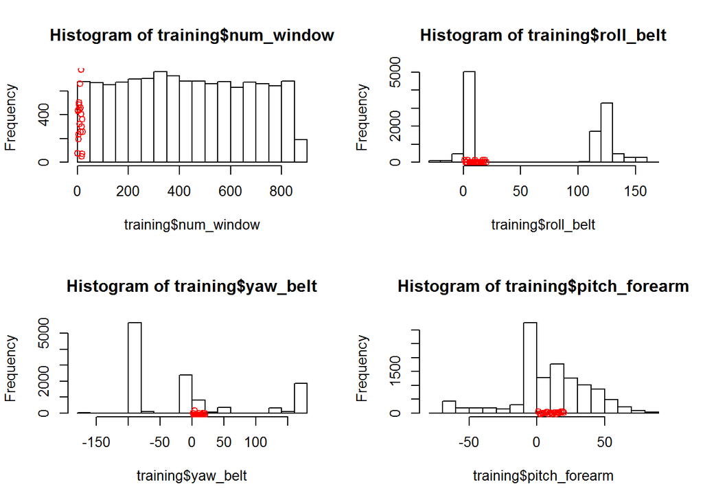